# JBA Shiny Training

29 June

## Problem

Basic Shiny apps can be stood up very quickly, however when building complex apps this ease of access can cause issues if not well understood

- We must optimise through reactivity and ensure a smooth user experience
- Strive for any functionality being visible in a single window

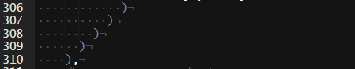

## Solution - Functions

Functionalise code, or more specifically for shiny, modularise code

- Functions are a fundamental principle to good coding

```r
add <- function(x,y){
  return(x+y)
}
add(2,4)
#>6
```

- You can give a function an evocative name that makes your code easier to understand.
- As requirements change, you only need to update code in one place, instead of many.
- You eliminate the chance of making incidental mistakes when you copy and paste (i.e. updating a variable name in one place, but not in another).

## Namespace Problem

inputs and outputs share a global namespace and have to be unique across an entire application

> If you’re using functions to generate UI, and those functions generate inputs and outputs, then you need to ensure that none of the IDs collide.

`plotOutput("graph1")`

`plotOutput("graph2")`

`plotOutput("graph3")`

`textOutput("graph1_text")`

`textOutput("graph2_text")`

`textOutput("graph3_text")`

## What Are Modules

- Modules can represent input, output, or both.
- They are functions that address shiny namespace issues.

```r
module_UI <- function(id) {
  ns <- NS(id)
  tagList(
    #UI elements
    )
}

module_server <- function(id) {
  moduleServer(
    id,
    function(input, output, session) {
      #Server logic
    }
  )
}
```

## What Are Modules

```r
randUI <- function(id) {
  ns <- NS(id)
  tagList(
    actionButton(ns("button"), label = "Generate"),
    verbatimTextOutput(ns("out"))
  )
}

randServer <- function(id) {
  moduleServer(
    id,
    function(input, output, session) {

      output$out <- renderText({
        input$button
        runif(1)
      })
    }
  )
}
```

## What Are Modules - Continued

```r
ui <- fluidPage(
  randUI("randomNumber")
)

server <- function(input, output, session) {
  randServer("randomNumber")
}

shinyApp(ui, server)
```

*01_slide_content.R*

## Closer Look - UI

```r
randUI <- function(id) {
  ns <- NS(id)
  tagList(
    actionButton(ns("button"), label = "Generate"),
    verbatimTextOutput(ns("out"))
  )
}
```

- A function that takes an `id` as the argument
- `NS()` is used within randUI to encapsulate the module’s UI
- common practice to assign `NS(id)` to `ns`
- any reference to an input within the module will now be surrounded by `ns()`
- returns a tagList of UI elements

```r
ns <- NS("randomNumber")
ns("button") # NS("randomNumber","button")
#randomNumber-button
```

## Closer Look - Server

```r
randServer <- function(id) {
  moduleServer(
    id,
    function(input, output, session) {

      output$out <- renderText({

        input$button

        runif(1)
      })
    }
  )
}
```

- A function that takes an `id` as the argument
- requires `moduleServer()` with two arguments, `id` and a server function
- any reference to an input within the module will be as normal

## Exercise 1 - Modularise a counting button

**exercise_01.R**

Bonus

- Make the module dynamic in the amount added
- Use apply family to create multiple counting buttons on a single app

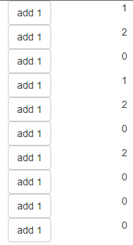

## Why Bother

- **Break down complicated code**
- Reusable
- R packages to be used by other Shiny authors

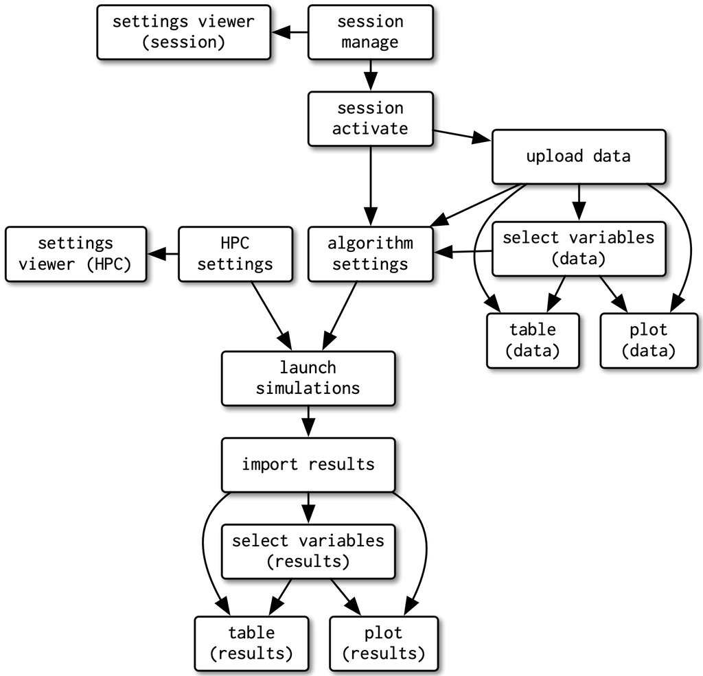

|

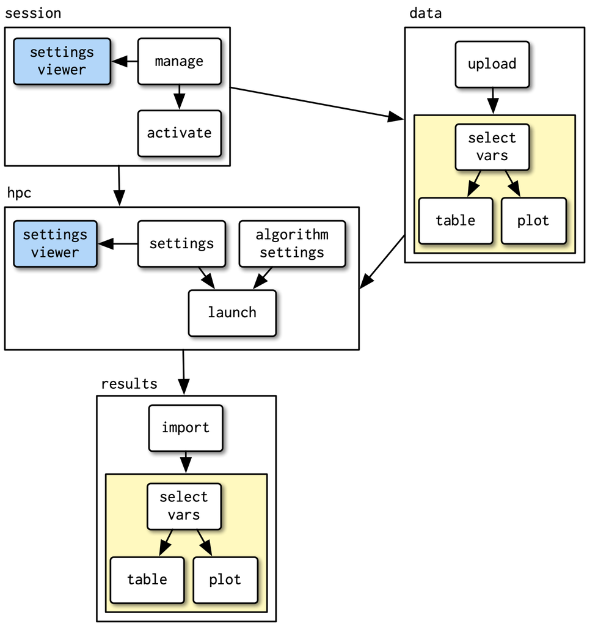

## Deciding When to Use Modules

- Consider a function when you see repeating code
- Consider a function when you see a large process that has clear inputs and outputs
- Use a module pair if this function involves UI and Server interaction

> Shiny’s module feature lets you break complicated UI and server logic into smaller, self-contained pieces. Compared to large monolithic Shiny apps, modules are easier to reuse and easier to reason about.

## Project Folder Structure

Keep modules together, in an R folder. Note refreshing apps

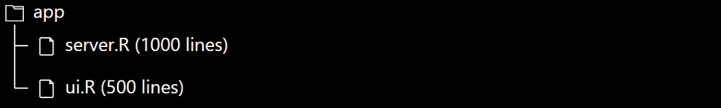

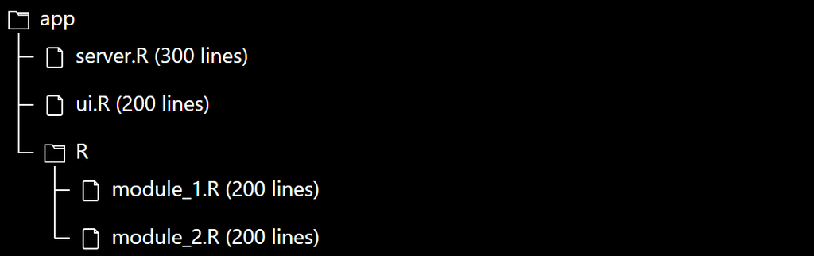

## Project Folder Structure

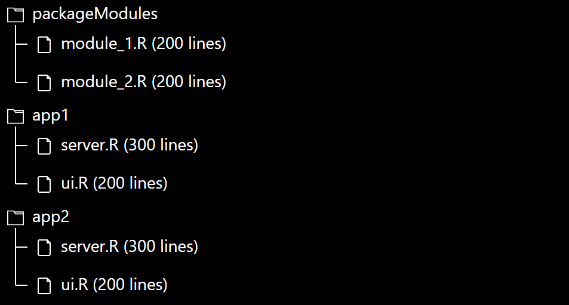

## Taking in Static Data

These are functions, so we can provide more than just an id.

```r
summary_server <- function(id, dataset) {
  moduleServer(
    id,
    function(input, output, session) {
      output$summary <- renderText(summary(dataset))
    }
  )
}
```

```r
server <- function(input, output, session) {
  summary_server("iris",iris)
  summary_server("cars",cars)
  summary_server("pressure",pressure)
}
```

*02_slide_content.R*

## Exercise 2 - Passing Static Objects

**exercise_02.R**

Modularlise the code to take any vector of numbers and custom heading.

Bonus: Provide data frame instead and dynamically choose column (vector)

## Taking in Reactive Data

Modules can take both static and reactive objects

```r
  val <- reactiveVal(1)

  vals <- reactiveValues(val_a = 1,
                         val_b = 2)

  dataset <- reactive({head(iris,input$nrows)})

  module_server(id = "id_1", arg1 = val) #Works
  module_server(id = "id_1", arg1 = val()) #Doesn't work

  module_server(id = "id_2", arg1 = vals) #Works
  module_server(id = "id_2", arg1 = vals$val_a) #Doesn't work

  module_server(id = "id_3", arg1 = dataset) #Works
  module_server(id = "id_3", arg1 = dataset()) #Doesn't work

  module_server(id = "id_4", arg1 = reactive({input$val})) #Works
  module_server(id = "id_4", arg1 = input$val) #Doesn't work
```

## Exercise 3 - Passing in Reactive Objects

**exercise_03.R**

Let the dataset be a reactive object that is passed to modules e.g histogram module based on dataset column

Bonus: explain and resolve the temporary error

## Nested Modules

- Modules can be nested
- This is great for breaking down complex apps into sub components e.g. dashboard

```r
library(shiny)

playerBreakDownUI <- function(id){
  ns <- NS(id)
  tagList(plotOutput(ns("plot")),
          tableOutput((ns("table"))),
          verbatimTextOutput(ns("summary_text"))
  )
}
```

*03_slide_content.R*

## Nested Modules

```r
overviewPageUI <- function(id){
  ns <- NS(id)

  fluidRow(
    column(6,playerBreakDownUI(ns("player"))),
    column(6, teamBreakDownUI(ns("team")))
  )

}

ui <- fluidPage(
  tabsetPanel(type = "tabs",
              tabPanel("Overview",
                       overviewPageUI("overview")),
              tabPanel("Plots",
                       plotPageUI("plot"))
  )
)
```

*04_slide_content.R*

## Composing Modules

Modules can return an object

```r
selectNumberServer <- function(id){

  moduleServer(id,function(input,output,session){

    my_row <- reactive(input$num)

    return(my_row)
  })
}

server <- function(input, output) {

  row_number <- selectNumberServer("sel")
  tableServer("tbl",row_number)

}
```

## Exercise 4 - Composing Modules

*exercise_04.R*

## Things to Note

- Modules were introduced in Shiny 0.13 (Jan 2016) with `callModule()` and overhauled in Shiny `1.5.0` (June 2020) with the introduction of `moduleServer()`
- `stopifnot(is.reactive(df))`, it is good practice to check each input to a module is either reactive or constant

## Workshop Exercise

Building a dashboard